# Exercise 1: Basic Demand Estimation Exercise

Reid Falconer

2018-11-21

### Summary

- In this exercise we will go through the standard steps that one needs to undertake in conducting a basic demand analysis. For this purpose, we will use scanner data obtained from Kraft. Kraft uses Nielsen as its scanner data vendor in all product categories. In this exercise, we use a small subset of all possible product/geography/ variable combinations available in this sort of data. We will explore store level-scanner data at the account level (Jewel), and at a higher of aggregation (Central Region).
- Category: Category: Viscous salad dressings (Mayonnaise/Miracle Whip/other “spreadables”)
- Sub-categories: Mayonnaise, Miracle Whip
- Product aggregates:
  - Kraft Mayo 32oz
  - Hellman’s Mayo 32oz
- Geographical aggregates:
  - Kraft Midwest Region (called “Central Region”)
  - Chicago Market: Jewel-Osco
- Time aggregation/periods:
  - Weekly data 91/92

## Data Check

##### 1. Construct a price variable by dividing $ sales by unit sales (employ the `sales_$` and `sales_u` variables). Explain how to interpret this price variable (i.e. what sort of average price is this?).

```r
price <- mydata$Sales_USD/mydata$Sales_U  # See `createVariables` function in `ex1hints.R`.
```

The ‘price’ variable is an average variable that is constructed by dividing the total weekly value (in US Dollars) of sales by the total weekly amount of sales (in equivalent units (lbs)). Therefore the ‘price’ variable is a weekly time-series of the average price of one unit (in equivalent units (lbs)) of the item (Kraft and Hellman’s Mayo in this example) in USD($).

##### 2. Compute the mean prices across weeks of Hellman’s in Jewel and the Central Region. Are they comparable? Repeat the exercise for Kraft in Jewel and the Central Region.

###### Hellman’s

```r
df_hellman <- na.omit(cbind(hellman_at_jewel$price, hellman_at_central$price)) %>%
  as.data.frame() %>%
  rename(hellman_at_jewel_price = V1,
         hellman_at_central_price = V2) %>%
  gather(region, value)

mu_hellman <- df_hellman %>% group_by(region) %>% summarize(grp_mean = mean(value))

t_test_hellman <- t.test(value ~ region, data = df_hellman)

df_hellman_ks <- na.omit(cbind(hellman_at_jewel$price, hellman_at_central$price)) %>%
  as.data.frame() %>%
  rename(hellman_at_jewel_price = V1,
         hellman_at_central_price = V2)

ks_hellman <- ks.test(df_hellman_ks$hellman_at_jewel_price,df_hellman_ks$hellman_at_central_price)
```

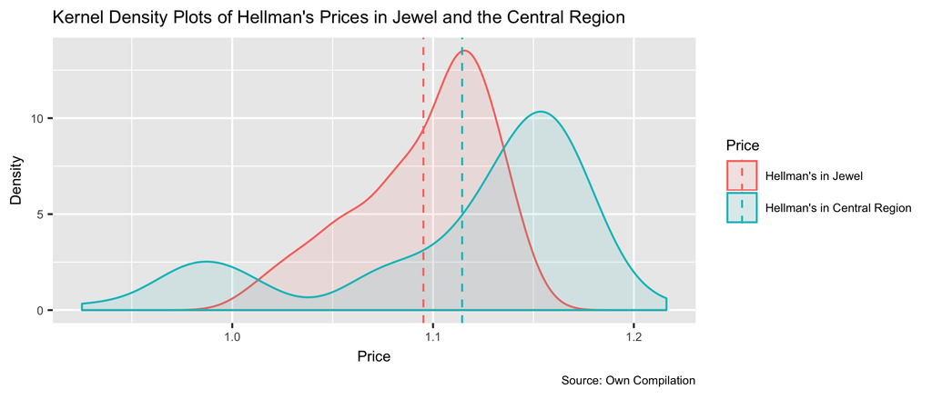

###### Kraft

```r
df_kraft <- na.omit(cbind(kraft_at_jewel$price, kraft_at_central$price)) %>%
  as.data.frame() %>%
  rename(kraft_at_jewel_price = V1,
         kraft_at_central_price = V2) %>%
  gather(region, value)

mu_kraft <- df_kraft %>% group_by(region) %>% summarize(grp_mean = mean(value))

t_test_kraft <- t.test(value ~ region, data = df_kraft)

df_kraft_ks <- na.omit(cbind(kraft_at_jewel$price, kraft_at_central$price)) %>%
  as.data.frame() %>%
  rename(kraft_at_jewel_price = V1,
         kraft_at_central_price = V2)

ks_kraft <- ks.test(df_kraft_ks$kraft_at_jewel_price,df_kraft_ks$kraft_at_central_price)
```

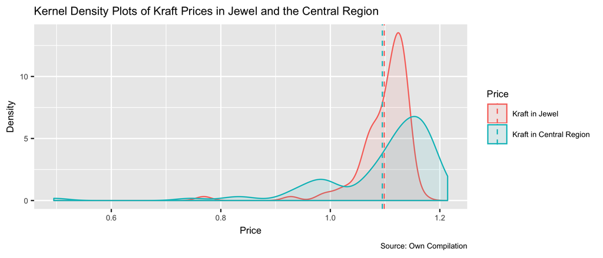

##### 3. Price variation: Compute the standard deviation of prices across weeks of Hellman’s in Jewel and the Central Region. Is there more price variation at Jewel or in the Central Region? Why? What does this tell you upfront about your ability to estimate price elasticities with either account level data or data in a large geographic market? Repeat the exercise for Kraft in Jewel and the Central Region.

```r
sd_hellman <- df_hellman %>% group_by(region) %>% summarize(grp_sd = sd(value))
sd_kraft <- df_kraft %>% group_by(region) %>% summarize(grp_sd = sd(value))
```

The standard deviation for Hellman’s in Jewel is noticeably greater than in the Central region. (0.067 vs 0.033 standard deviation respectively). Similarly, the standard deviation for Kraft in Jewel is significantly larger than in the Central region. (0.112 and 0.053 standard deviation respectively). Generally speaking, more variation means more ‘information’, and thus the larger amount of variation in Jewel should improve our ability to accurately estimate the price elasticities with the account level data compared to the Central region data. Additionally, one can attribute the lower variation found in the Central region to the data creation process, as aggregation over values usually results in lower variability.

##### 4. Price plots: Construct time-series plots of sales and prices for Hellman’s in the Central division and for Jewel (i.e. weeks on the X-axis, prices and unit-sales on the Y-axis). Repeat the exercise for Kraft. Describe the differences or similarities between Kraft and Hellman’s pricing policies in each account.

###### Hellman’s

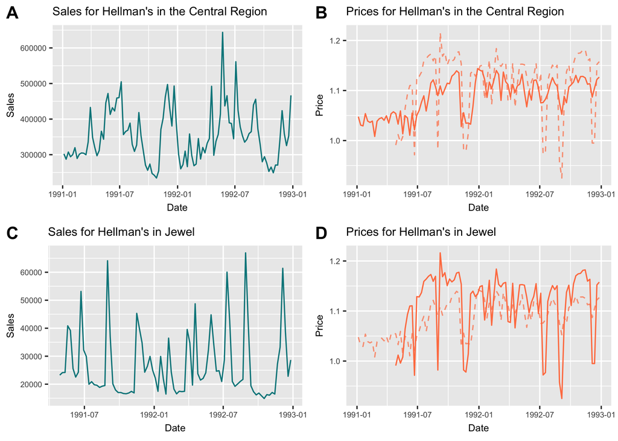

Hellman’s pricing policies in the Central Region and for Jewel appear to follow a similar pattern over time (comparisons can effectively be made by viewing the dashed lines which highlight the price time-series plots in the ‘other’ Region). One notable difference (that was statistically identified in the question above) is that Hellman’s pricing policy seems to be more variable in Jewel (with higher peaks and lower troughs). The sales plots are harder to draw inference from but a clear inverse relationsip between sales and prices can be seen.

###### Kraft

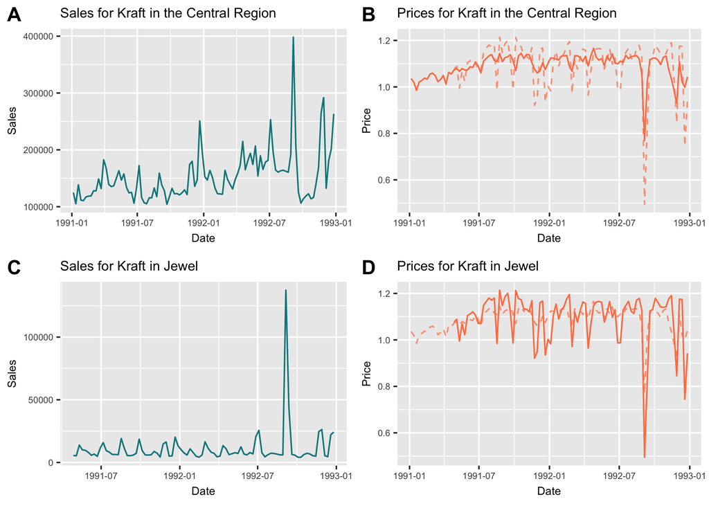

Kraft’s pricing policies also follow a similar pattern over time in both the Central Region and Jewel. Similar to Hellman’s, Kraft’s pricing policy is shown to have more variation in Jewel than in the Central Region (with higher peaks and lower troughs). Once again, the sales plots are tricky to compare (given the difference in scales) but an inverse relationship between sales and prices is clearly prevalent.

###### Price Plots

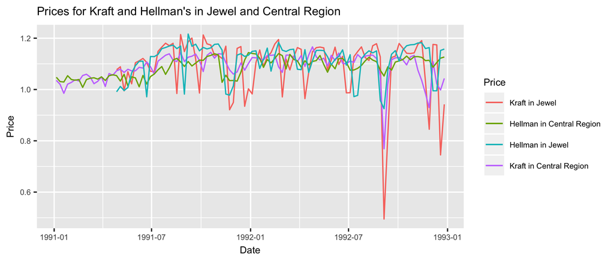

The above plot illustrates the time-series plots of prices for both Kraft and Hellman’s in the Central Region and Jewel. This highlights how all the pricing policies vary consistently and move together over time. Furthermoe, the plot highlights the more substantial variations found in Jewel for both Kraft and Hellman’s. In a more in-depth analysis, it would be useful to plot the percentage change in sales and prices over time as these would be more comparable and add some valuable insights.

##### 5. Scatter-plots: Construct scatter-plots of sales versus prices for Hellman’s in the Central division and for Jewel (i.e. prices on the Y-axis, unit-sales on the X-axis). Repeat the exercise for Kraft. Is there evidence for a negatively sloped demand-curve in the data? Eye-balling these plots, does demand appear more elastic in the Central Region or at Jewel (for either Hellman’s or Kraft)?

###### Hellman’s

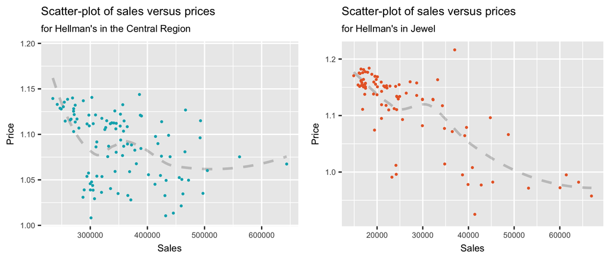

Looking at the two plots above there is evidence for a negatively sloped demand-curve in the data for Hellman’s in both the Central Region and at Jewel. Eye-balling these plots, demand appears to be more elastic at Jewel where a percentage change in price will seem to produce a greater percentage change in quantity demanded.

###### Kraft

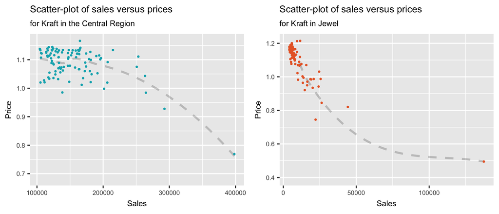

Looking at the two plots above there is evidence for a negatively sloped demand-curve in the data for Kraft in both the Central Region and at Jewel. Eye-balling these plots, demand appears to be more elastic at Jewel where a percentage change in price will seem to produce a greater percentage change in quantity demanded.

## Demand Estimation

##### 1. Fit the “multiplicative” demand model discussed in class for Kraft and Hellman’s at Jewel (i.e. 2 separate regressions, one for Hellman’s, and one for Kraft).

#### Hellman and Kraft at Jewel

```r
model_1 <- runRegression(hellman_at_jewel)
model_2 <- runRegression(kraft_at_jewel)
```

**Sales of Hellman at Jewel**

|  | ln(Hellman Sales) |
| --- | --- |
|  | *OLS* |
| ln(Hellman price) | -4.580*** |
|  | (0.427) |
| Constant | 10.600*** |
|  | (0.053) |
| Observations | 88 |
| R<sup>2</sup> | 0.573 |
| Adjusted R<sup>2</sup> | 0.568 |
| Residual Std. Error | 0.248 (df = 86) |
| F Statistic | 115.000*** (df = 1; 86) |
| *Note:* | p<0.1; p<0.05; p<0.01 |

**Sales of Kraft at Jewel**

|  | ln(Kraft Sales) |
| --- | --- |
|  | *OLS* |
| ln(Kraft price) | -4.170*** |
|  | (0.254) |
| Constant | 9.400*** |
|  | (0.038) |
| Observations | 88 |
| R<sup>2</sup> | 0.758 |
| Adjusted R<sup>2</sup> | 0.756 |
| Residual Std. Error | 0.292 (df = 86) |
| F Statistic | 270.000*** (df = 1; 86) |
| *Note:* | p<0.1; p<0.05; p<0.01 |

##### 2. Fit the “multiplicative” demand model discussed in class for Kraft and Hellman’s for the Central Region (i.e. 2 separate regressions, one for Hellman’s, and one for Kraft).

#### Hellman and Kraft at Central

```r
model_3 <- runRegression(hellman_at_central)
model_4 <- runRegression(kraft_at_central)
```

**Sales of Hellman at Central**

|  | ln(Hellman Sales) |
| --- | --- |
|  | *OLS* |
| ln(Hellman price) | -2.380*** |
|  | (0.551) |
| Constant | 12.900*** |
|  | (0.049) |
| Observations | 104 |
| R<sup>2</sup> | 0.154 |
| Adjusted R<sup>2</sup> | 0.146 |
| Residual Std. Error | 0.190 (df = 102) |
| F Statistic | 18.600*** (df = 1; 102) |
| *Note:* | p<0.1; p<0.05; p<0.01 |

**Sales of Kraft at Central**

|  | ln(Kraft Sales) |
| --- | --- |
|  | *OLS* |
| ln(Kraft price) | -2.110*** |
|  | (0.401) |
| Constant | 12.100*** |
|  | (0.040) |
| Observations | 104 |
| R<sup>2</sup> | 0.213 |
| Adjusted R<sup>2</sup> | 0.205 |
| Residual Std. Error | 0.218 (df = 102) |
| F Statistic | 27.600*** (df = 1; 102) |
| *Note:* | p<0.1; p<0.05; p<0.01 |

##### 3. Elasticity differences: Is the demand elasticity higher (in absolute magnitude) at the Jewel account or in the Central Region? Can you offer some compelling explanations for the difference? (think of as many potential reasons as possible)

```r
data.frame(
  product = c("Hellman at Jewel", "Kraft at Jewel","Hellman at Central","Kraft at Central"),
  elas = c(abs(tidy_model_1$estimate[2]), abs(tidy_model_2$estimate[2]), abs(tidy_model_3$estimate[2]), abs(tidy_model_4$estimate[2]))) %>%
  mutate(elas = formattable::color_bar("lightgrey")(elas)) %>%
  rename(`Elasticity (in absolute magnitude)` = elas,
         `Product and Region` = product)  %>%
  kable("html", escape = F) %>%
  kable_styling("striped", full_width = T) %>%
  column_spec(1, bold = T) %>%
  row_spec(0, bold = T, color = "white", background = "#0399a8")
```

| Product and Region | Elasticity (in absolute magnitude) |
| --- | --- |
| Hellman at Jewel | 4.58 |
| Kraft at Jewel | 4.17 |
| Hellman at Central | 2.38 |
| Kraft at Central | 2.11 |

The demand elasticity is higher (in absolute magnitude) at the Jewel account for both Hellman’s and Kraft than in the Central Region. While demand is normally anticipated to be elastic at the brand level, these differences in the elasticity of demand can be possibly be explained by a number of factors.

- Availability of Substitutes
  - The more substitutes available to a customer, the more elastic a product’s demand. Therefore, it may be the case that there are more viscous salad dressing (Mayonnaise/Miracle Whip/other “spreadables”) substitutes available at the Jewel account than in the Central Region.
  - The Jewel account may also have more shops in close proximity making it easier for consumers to switch than it is in the Central Region.
- Consumer Preferences
  - It is conceivable to believe that consumers in the Central Region have stronger salad dressing preferences than those at the Jewel account and are thus more likely to pay what is asked to get what they want, making the demand elasticity less elastic in the Central Region compared to the Jewel account.
- Consumer Income:
  - The income of the consumer also affects the elasticity of demand. It is possible that consumers in the Central Region are from higher-income groups than those at the Jewel account. Therefore, the demand in the Central Region will be less elastic as the rise or fall in the price will not have as much effect on the demand for the product (salad dressing).

##### 4. Forecasting demand under a price change: Using your regression results from the multiplicative demand model, compute the % change in unit sales for a 10% increase in the price of Kraft and Hellman’s at Jewel. (Note: You can do this brute force in Excel, but for your benefit you should try to compute this on a sheet of paper with the help of a calculator).

###### Hellman at Jewel

```r
# To get the proportional change in Y associated with a p percent increase in X, calculate
# a = ([100 + p]/100) and take a^β
price_coeff <- tidy_model_1$estimate[2]

compute_change <- function(percent_change, price_coeff) {
  a <- ((100 + percent_change)/100)
  price_effect <- a^price_coeff
  if (price_effect < 1) {
  prop <- (1-price_effect)*100
  direction <- "% decrease"
  }  else {
  prop <- (price_effect - 1)*100
  direction <- "% increase"
  }
  return(list(phrase = (paste0(round(prop, digits = 2), direction)), numeric = prop))
}

change_hellman <- compute_change(10, price_coeff)
```

A 10% increase in the price of Hellman’s at Jewel results in a 35.39% decrease in unit sales of Hellman’s at Jewel, ceteris paribus.

###### Kraft at Jewel

```r
# To get the proportional change in Y associated with a p percent increase in X, calculate
# a = ([100 + p]/100) and take a^β
price_coeff <- tidy_model_2$estimate[2]

compute_change <- function(percent_change, price_coeff) {
  a <- ((100 + percent_change)/100)
  price_effect <- a^price_coeff
  if (price_effect < 1) {
  prop <- (1-price_effect)*100
  direction <- "% decrease"
  }  else {
  prop <- (price_effect - 1)*100
  direction <- "% increase"
  }
  return(list(phrase = (paste0(round(prop, digits = 2), direction)), numeric = prop))
}

change_kraft <- compute_change(10, price_coeff)
```

A 10% increase in the price of Kraft at Jewel results in a 32.78% decrease in unit sales of Kraft at Jewel, ceteris paribus.

##### 5. Focus on the data for Kraft and Hellman’s 32 oz at Jewel. Fit the “multiplicative” demand model for Kraft and Hellman’s at Jewel allowing for cross-price effects (i.e. 2 separate regressions, one for Hellman’s, and one for Kraft, with Hellman’s own price and Kraft’s price affecting sales of Hellman’s; and Kraft’s own price and Hellman’s price affecting sales of Kraft).

#### Hellman and Kraft at Jewel

```r
model_5 <- lm(ln_sales_u ~ ln_price.x + ln_price.y, data = hellman.jewel_kraft.price)
# x = kraft_at_jewel
# y = hellman_at_jewel

model_6 <- lm(ln_sales_u ~ ln_price.x + ln_price.y, data = kraft.jewel_hellman.price)
# x = hellman_at_jewel
# y = kraft_at_jewel
```

**Sales of Hellman at Jewel**

|  | ln(Hellman Sales) |
| --- | --- |
|  | *OLS* |
| ln(Kraft price) | 0.196 |
|  | (0.225) |
| ln(Hellman price) | -4.700*** |
|  | (0.446) |
| Constant | 10.600*** |
|  | (0.053) |
| Observations | 88 |
| R<sup>2</sup> | 0.577 |
| Adjusted R<sup>2</sup> | 0.567 |
| Residual Std. Error | 0.249 (df = 85) |
| F Statistic | 57.900*** (df = 2; 85) |
| *Note:* | p<0.1; p<0.05; p<0.01 |

**Sales of Kraft at Jewel**

|  | ln(Kraft Sales) |
| --- | --- |
|  | *OLS* |
| ln(Hellman price) | 1.870*** |
|  | (0.486) |
| ln(Kraft price) | -4.440*** |
|  | (0.246) |
| Constant | 9.220*** |
|  | (0.058) |
| Observations | 88 |
| R<sup>2</sup> | 0.794 |
| Adjusted R<sup>2</sup> | 0.789 |
| Residual Std. Error | 0.271 (df = 85) |
| F Statistic | 164.000*** (df = 2; 85) |
| *Note:* | p<0.1; p<0.05; p<0.01 |

##### 6. You may be called upon to report to your manager whether your brand is vulnerable to a competitor’s pricing policies. That is, to what extent does the demand for your product depend on (or is affected by) your competitors’ pricing policy? From the results in 5, which brand is more “vulnerable”? Be specific as to why.

Kraft at Jewel seems to be more “vulnerable” to Hellman’s pricing policy than Hellman’s is to Kraft’s pricing policy at Jewel. This is motivated by the above regression analysis, where it is shown that Kraft’s sales at Jewel are significantly affected by Hellman’s price (with a large and statistically significant coefficient of 1.871 at the 1% level of significance), whereas Hellman’s sales at Jewel are insignificantly affected by Kraft’s price (with a small and insignificant coefficient of 0.196).

##### 7. While making a crucial presentation of the above results in front of your team, your analyst colleague questions your results as follows: “This is all fine. But, you know, you’re missing a lot of variables in your so-called regression model. For instance, the sales of Kraft mayo at Jewel are clearly affected by store traffic. When it snows, less people visit Jewel, and you don’t have such factors – the weather, temperature, traffic congestions, etc. So aren’t your cross-price effects all wrong?” Is your colleague right or wrong?

My colleague is correct as they are a number of omitted variables that are potentially correlated with both the price and sales of Kraft and Hellman’s mayo at Jewel but are unobserved. This would lead to omitted variable bias.

In reality, it very rarely happens that we have access to a dataset that allows us to control for all factors that could conceivably bias the estimated effect of price on sales. Therefore, we cannot expect OLS, or any estimator that relies on regressor exogeneity for identification, to produce consistent estimates of the population model parameters. In such cases, we should consider using an alternative strategy to identify our price elasticities of interest.

##### 8. Suppose you work at Kraft, and you realize that Hellman’s price is cut by 10% at Jewel. Using your estimates from 5, compute by what percent you have to lower the Kraft 32 oz price at Jewel to obtain the same sales as you currently enjoy.

```r
hellman_coeff <- tidy_model_6$estimate[2]
kraft_coeff <- tidy_model_6$estimate[3]

compute_change <- function(percent_change, price_coeff) {
  a <- ((100 + percent_change)/100)
  price_effect <- a^price_coeff
  if (price_effect < 1) {
  prop <- (1-price_effect)*100
  direction <- "% decrease"
  }  else {
  prop <- (price_effect - 1)*100
  direction <- "% increase"
  }
  return(list(phrase = (paste0(round(prop, digits = 2), direction)), numeric = prop))
}
# Hellman’s price is cut by 10% at Jewel
change <- compute_change(-10, hellman_coeff)

# A function to aid with solving
f <- function(x)  (((((100 - x)/100)^kraft_coeff)-1)*100 - ((100/(100-change$numeric))-1)*100
                   )
percent <- uniroot(f, lower=0, upper=100)$root
```

If Hellman’s price is cut by 10% at Jewel, using our estimates from 5, we (at Kraft) would have to lower the Kraft 32 oz price at Jewel by 4.345% to obtain the same sales that we currently enjoy (see the code above for explicit calculation).